# STAAR analysis

## Notebook setup

# Distributions of STAAR scores

This computes the distribution of all science STAAR scores.

````r
```r
df_staar_science %>%
  select(SubjectCode,
         GradeLevelID,
         Approaches,
         Meets,
         Masters) %>%
  group_by(SubjectCode,
           GradeLevelID) %>%
  summarize(nStudents = n(),
            nApproaches = sum(Approaches),
            nMeets = sum(Meets),
            nMasters = sum(Masters)) %>%
  mutate(PercentApproaches = nApproaches/nStudents,
         PercentMeets = nMeets/nStudents,
         PercentMasters = nMasters/nStudents)
````

Adding missing grouping variables: `` StudentNumber``summarise() `` has grouped output by ‘SubjectCode’. You can override using the `.groups` argument.

[output not shown]

`summarise()` has grouped output by ‘SubjectCode’. You can override using the `.groups` argument.

[output not shown]

`summarise()` has grouped output by ‘SubjectCode’. You can override using the `.groups` argument.

[output not shown]

[output not shown]

[output cut: 21 more lines]

```r
(staar_approaches_by_dose <- df_staar_science_survey_takers %>%
  select(SubjectCode,
         GradeLevelID.x,
         CRDoseGroup,
         Approaches,
         Meets,
         Masters) %>%
  group_by(SubjectCode,
           GradeLevelID.x,
           CRDoseGroup) %>%
  summarize(nStudents = n(),
            nApproaches = sum(Approaches),
            nDoesNotApproach = n() - sum(Approaches)))
```

| SubjectCode | GradeLevelID.x | CRDoseGroup | nStudents | nApproaches | nDoesNotApproach |
| --- | --- | --- | --- | --- | --- |
| Biology | 8 | 0-2 Visits | 11 | 9 | 2 |
| Biology | 8 | More Than 2 Visits | 12 | 12 | 0 |
| Biology | 9 | 0-2 Visits | 6 | 5 | 1 |
| Biology | 9 | More Than 2 Visits | 15 | 15 | 0 |
| Biology | 10 | 0-2 Visits | 4 | 3 | 1 |
| Biology | 10 | More Than 2 Visits | 1 | 1 | 0 |
| Science | 5 | 0-2 Visits | 90 | 77 | 13 |
| Science | 5 | More Than 2 Visits | 64 | 52 | 12 |
| Science | 8 | 0-2 Visits | 9 | 9 | 0 |
| Science | 8 | More Than 2 Visits | 9 | 9 | 0 |

[output cut: 21 more lines]

Because there are many groups where there are zero students not approaching, tests on proportions may not be appropriate, unless groups are combined and/or a different value is measured. Note that even if we combined all 8th-10th groups with more than 2 visits, there would still be a zero observations category (did not approach AND more than 2 visits).

## Tests on dosage

This was not working when I tried it - will try again on Mon, July 25.

# Distributions of STAAR Scale Score

```r
df_staar_science_survey_takers %>%
  filter(SubjectCode %in% c("Science", "Biology")) %>%
  group_by(GradeLevelID.x, SubjectCode, CRDoseGroup) %>%
  summarize(n = n(),
            MeanScaleScore = mean(ScaleScore, na.rm=TRUE))
```

| GradeLevelID.x | SubjectCode | CRDoseGroup | n | MeanScaleScore |
| --- | --- | --- | --- | --- |
| 5 | Science | 0-2 Visits | 90 | 4151.089 |
| 5 | Science | More Than 2 Visits | 64 | 3973.641 |
| 8 | Biology | 0-2 Visits | 11 | 3999.455 |
| 8 | Biology | More Than 2 Visits | 12 | 4113.167 |
| 8 | Science | 0-2 Visits | 9 | 4685.000 |
| 8 | Science | More Than 2 Visits | 9 | 4900.111 |
| 9 | Biology | 0-2 Visits | 6 | 3809.000 |
| 9 | Biology | More Than 2 Visits | 15 | 4553.733 |
| 10 | Biology | 0-2 Visits | 4 | 4177.750 |
| 10 | Biology | More Than 2 Visits | 1 | 3658.000 |

## Tests on dosage

- Normality check

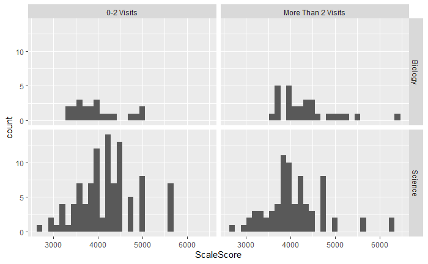

```r
df_staar_science_survey_takers %>%
  filter(SubjectCode %in% c("Biology", "Science")) %>%
  ggplot() +
  geom_histogram(aes(x = ScaleScore)) +
  facet_grid(SubjectCode ~ CRDoseGroup)
```

```r
NA
NA
```